# Assignment 2, EDDA 2017

Fabio Curi Paixao (2592802) Arash Parnia (2591051) - Group 22

19 April 2017

## Introduction

In the present document, the results for the second and third assignment of the EDDA course are presented.

## Assignment 2

### EXERCISE 1

#### 1. Test whether the data in telephone.txt stems from the exponential distribution Exp(λ) with λ = 0.035, by performing a bootstrap test using the test statistic T(X1, . . . , XN ) = median(X1, . . . , XN ).

```r
telephone = read.table('telephone.txt')
d <- as.numeric(levels(telephone$V1))[telephone$V1]
```

```
NAs introduced by coercion
```

```r
d <- d[!is.na(d)]
shapiro.test(d)
```

```
    Shapiro-Wilk normality test

data:  d
W = 0.85813, p-value = 1.085e-12
```

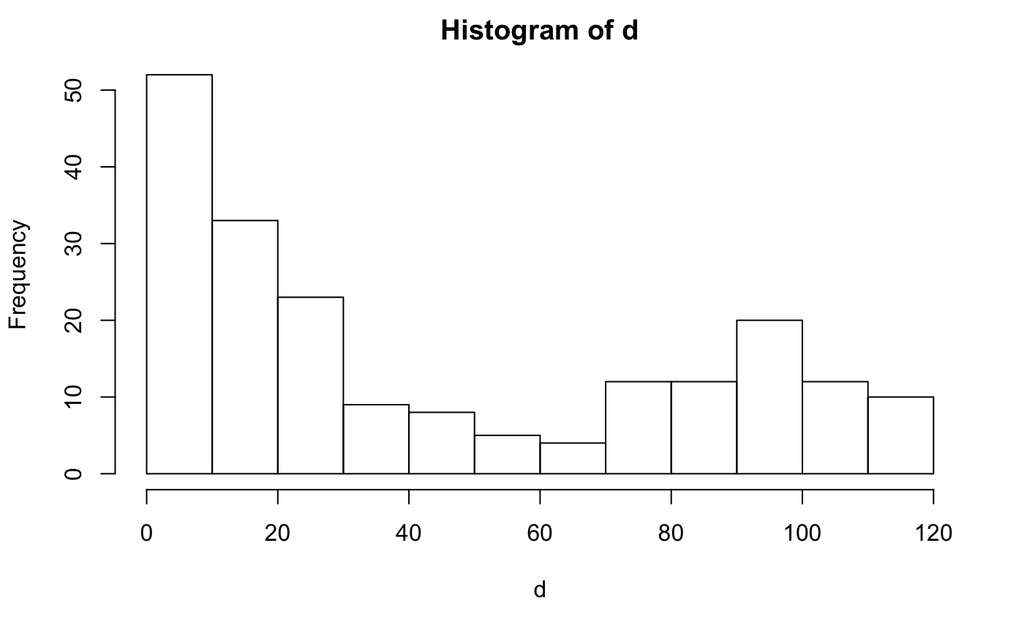

```r
hist(d)
```

```r
# m = Filter(is.numeric, mydata)
# length(d) # number of elements or components
# str(d)    # structure of an object
# class(d)  # class or type of an object
# names(d)  # names
B=1000
Tstar=numeric(B)
for(i in 1:B){
  Xstar=sample(d,replace=TRUE)
  Tstar[i]=median(Xstar)
}
Tstar25=quantile(Tstar,0.025)
Tstar975=quantile(Tstar,0.975)
sum(Tstar<Tstar25)
```

```
[1] 22
```

```r
T1 = mean(d)
c(2*T1-Tstar975,2*T1-Tstar25)
```

```
  97.5%    2.5%
52.8152 66.9202
```

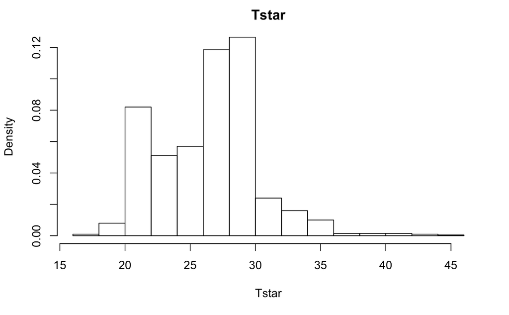

```r
hist(Tstar,prob=T1,main="Tstar")
```

#### 2. Make an appropriate plot of this data set. What information can be extracted from these data? What marketing advice would you give to the marketing manager?

## EXERCISE 2

#### 1. Make histograms and box plots of the data sets. What do you observe?

First of all, we will make the adjusments necessary for the three databases to be able to be compared. These adjustments are needed since the measurement procedures between both scientists were different.

```r
# light1879 = read.delim('light1879.txt',sep = "",header = FALSE)
# light1882 = read.delim('light1882.txt',sep = "",header = FALSE)
# light = read.delim('light.txt',sep = "",header = FALSE)
light1879 = scan(file="light1879.txt")
```

```
Read 100 items
```

```r
light1882 = scan(file="light1882.txt")
```

```
Read 23 items
```

```r
light = scan(file="light.txt")
```

```
Read 66 items
```

```r
light = light/1000  + 24.8
light = 7.442 * 1000 /light
light = light * 1000

light  = light -299000
# light1879 <- c(light1879$V1,light1879$V2,light1879$V3,light1879$V4,light1879$V5)
# light1882 <- c(light1882$V1,light1882$V2,light1882$V3,light1882$V4,light1882$V5)
# light1882 <- light1882[!is.na(light1882)]
# light <- light$V1
#
# light1879 = light1879 + 299000
# light1882 = light1882 + 299000
# light1879 = light1879 /1000
# light1882 = light1882 / 1000
#
#
# light = light + (24.8)
#  light = (7442 / light )

light = light[light > 0]
par(mfrow=c(1,3))
hist(light1879,prob = T)
hist(light1882,prob = T)
```

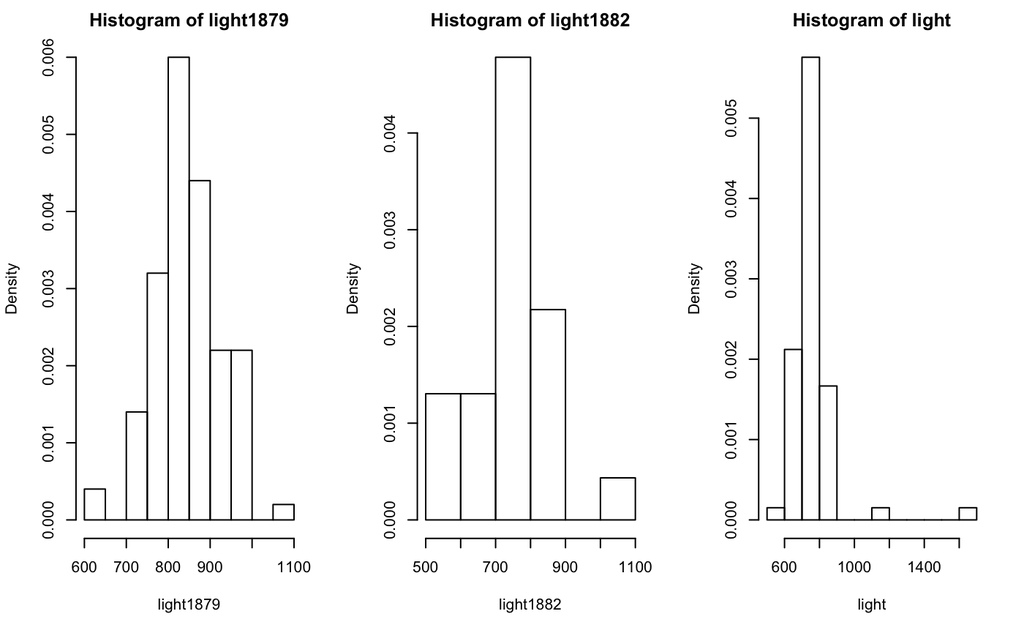

```r
hist(light,prob = T)
par(mfrow=c(1,3))
```

```r
boxplot(light1879)
boxplot(light1882)
```

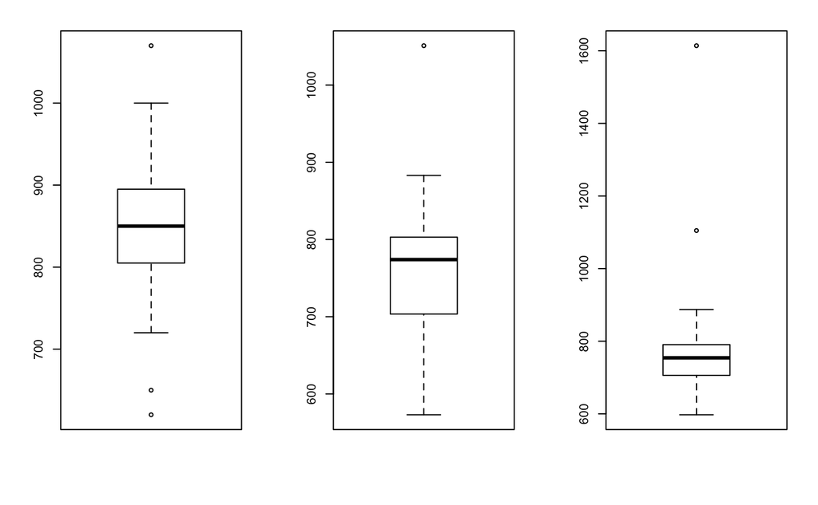

```r
boxplot(light)
```

```r
#l1 = as.numeric(levels(light1879))[light1879]
```

As it can be seen from the boxplots, there is a significant difference between the measurements made in 1879 by Michelson in 1879 and 1882 and from Newcomb’s measurements from 1882. The median values of the boxplots are considerably different between the former and these two last. Furthermore, between the two measurements from 1882, Newcomb managed to obtain his results in a fairly narrower amplitude, which is maybe thanks to his methodology and/or equipments used.

#### 2. Determine confidence intervals for the speed of light in km/sec for all three data sets (use population means and medians).

```r
# for means
mean(light1879)
```

```
[1] 852.4
```

```r
B=1000
T1 = mean(light1879)
d = light1879
Tstar=numeric(B)
for(i in 1:B){
  Xstar=sample(d,replace=TRUE)
  Tstar[i]=median(Xstar)
}
Tstar25=quantile(Tstar,0.025)
Tstar975=quantile(Tstar,0.975)
sum(Tstar<Tstar25)
```

```
[1] 20
```

```r
T1 = mean(d)
c(2*T1-Tstar975,2*T1-Tstar25)
```

```
97.5%  2.5%
834.8 864.8
```

```r
mean(light1882)
```

```
[1] 756.2174
```

```r
B=1000
T1 = mean(light1882)
d = light1882
Tstar=numeric(B)
for(i in 1:B){
  Xstar=sample(d,replace=TRUE)
  Tstar[i]=median(Xstar)
}
Tstar25=quantile(Tstar,0.025)
Tstar975=quantile(Tstar,0.975)
sum(Tstar<Tstar25)
```

```
[1] 9
```

```r
T1 = mean(d)
c(2*T1-Tstar975,2*T1-Tstar25)
```

```
   97.5%     2.5%
715.4348 801.4348
```

```r
mean(light)
```

```
[1] 763.8681
```

```r
B=1000
T1 = mean(light)
d = light
Tstar=numeric(B)
for(i in 1:B){
  Xstar=sample(d,replace=TRUE)
  Tstar[i]=median(Xstar)
}
Tstar25=quantile(Tstar,0.025)
Tstar975=quantile(Tstar,0.975)
sum(Tstar<Tstar25)
```

```
[1] 16
```

```r
T1 = mean(d)
c(2*T1-Tstar975,2*T1-Tstar25)
```

```
   97.5%     2.5%
761.3622 791.5458
```

```r
# for median
median(light1879)
```

```
[1] 850
```

```r
B=1000
T1 = median(light1879)
d = light1879
Tstar=numeric(B)
for(i in 1:B){
  Xstar=sample(d,replace=TRUE)
  Tstar[i]=median(Xstar)
}
Tstar25=quantile(Tstar,0.025)
Tstar975=quantile(Tstar,0.975)
sum(Tstar<Tstar25)
```

```
[1] 18
```

```r
T1 = mean(d)
c(2*T1-Tstar975,2*T1-Tstar25)
```

```
97.5%  2.5%
834.8 864.8
```

```r
median(light1882)
```

```
[1] 774
```

```r
B=1000
T1 = median(light1882)
d = light1882
Tstar=numeric(B)
for(i in 1:B){
  Xstar=sample(d,replace=TRUE)
  Tstar[i]=median(Xstar)
}
Tstar25=quantile(Tstar,0.025)
Tstar975=quantile(Tstar,0.975)
sum(Tstar<Tstar25)
```

```
[1] 9
```

```r
T1 = mean(d)
c(2*T1-Tstar975,2*T1-Tstar25)
```

```
   97.5%     2.5%
716.4348 801.4348
```

```r
median(light)
```

```
[1] 754.2998
```

```r
B=1000
T1 = median(light)
d = light
Tstar=numeric(B)
for(i in 1:B){
  Xstar=sample(d,replace=TRUE)
  Tstar[i]=median(Xstar)
}
Tstar25=quantile(Tstar,0.025)
Tstar975=quantile(Tstar,0.975)
sum(Tstar<Tstar25)
```

```
[1] 23
```

```r
T1 = mean(d)
c(2*T1-Tstar975,2*T1-Tstar25)
```

```
   97.5%     2.5%
761.3622 791.5458
```

#### 3. Comment on the intervals found.

#### 4. Find on the internet the currently most accurate value for the speed of light. Is it consistent with the measurements of Michelson and Newcomb?

speed of light is 299792458 m / s and 299792.458 kps

## EXERCISE 3

#### 1. Test (using an appropriate test) the null hypothesis that the median duration µ is smaller or equal to 32 days against the alternative hypothesis that this median is greater than 32 days. Motivate your choice of test.

We will now test the null hypothesis that the median duration is smaller or equal to 32 days against the alternative hypothesis that this median is greater than 32 days.

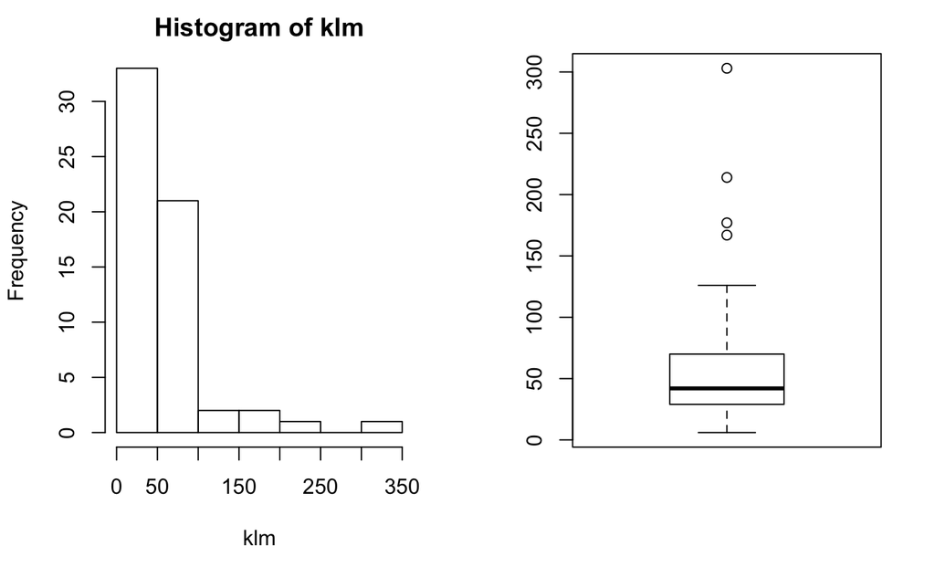

```r
klm = read.table('klm.txt')
klm = c(klm$V1,klm$V2,klm$V3,klm$V4,klm$V5)
par(mfrow=c(1,2))
hist(klm)
boxplot(klm)
```

```r
summary(klm)
```

```
   Min. 1st Qu.  Median    Mean 3rd Qu.    Max.
   6.00   29.00   42.00   57.73   70.00  303.00
```

```r
library(BSDA)
p <- SIGN.test(klm , md = 32)
```

```
    One-sample Sign-Test

data:  klm
s = 37, p-value = 0.03314
alternative hypothesis: true median is not equal to 32
95 percent confidence interval:
 32.00000 56.07713
sample estimates:
median of x
         42
```

```r
p
```

```
                  Conf.Level L.E.pt  U.E.pt
Lower Achieved CI     0.9481     32 56.0000
Interpolated CI       0.9500     32 56.0771
Upper Achieved CI     0.9727     32 57.0000
```

#### 2. KLM is willing to accept that (on average over a long period) at most 10% of the parts arrives after the maximum delivery period of 70 days. Design a test analogously to the sign test to check whether this criterium is met. Perform this test on the KLM data.

```r
wilcox.test(klm,mu=70)
```

```
    Wilcoxon signed rank test with continuity correction

data:  klm
V = 360.5, p-value = 0.0001286
alternative hypothesis: true location is not equal to 70
```

## EXERCISE 4

#### 1. Test whether silver nitrate has an effect by performing three tests: the two samples t-test (argue whether the data are paired or not), the MannWhitney test and the Kolmogorov-Smirnov test. Indicate whether these tests are applicable for our research question. Comment on your findings.

To see if there was an improvement, deterioration, or if the means of times have remained substantially the same (hypothesis H0), we need to make a Student’s t-test for paired samples:

```r
# clouds = read.table('clouds.txt',header = FALSE)
# par(mfrow=c(1,3))
# plot(V1~V2,data=clouds); abline(0,1)
# boxplot(clouds$V1)
# boxplot(clouds[,1]-clouds[,2])
clouds = read.table('clouds.txt',header = FALSE)
a=as.numeric(levels(clouds$V1))[clouds$V1]
```

```
NAs introduced by coercion
```

```r
a=a[2:end(a)]
```

```
numerical expression has 2 elements: only the first used
```

```r
b=as.numeric(levels(clouds$V2))[clouds$V2]
```

```
NAs introduced by coercion
```

```r
b=b[2:end(b)]
```

```
numerical expression has 2 elements: only the first used
```

To see if there was an improvement, deterioration, or if the means of times have remained substantially the same (hypothesis H0), we need to make a Student’s t-test for paired samples:

```r
t.test(a,b, paired=TRUE)
```

```
    Paired t-test

data:  a and b
t = 2.1204, df = 25, p-value = 0.04407
alternative hypothesis: true difference in means is not equal to 0
95 percent confidence interval:
   7.961957 546.883428
sample estimates:
mean of the differences
               277.4227
```

```r
print(wilcox.test(a,b,paired=TRUE) )
```

```
    Wilcoxon signed rank test

data:  a and b
V = 281, p-value = 0.006131
alternative hypothesis: true location shift is not equal to 0
```

The null hypothesis is that the rainfall of the two sample unseeded and seeded clouds are identical populations. As the p-value turns out to be 0.006131, and is less than the .05 significance level, we reject the null hypothesis.

```r
print(ks.test(a,b,paired=TRUE))
```

```
cannot compute exact p-value with ties
```

```
    Two-sample Kolmogorov-Smirnov test

data:  a and b
D = 0.42308, p-value = 0.01905
alternative hypothesis: two-sided
```

Here, the same conclusion can be made, as the p-value for is below 0.05. In the present case, applying these three tests might not be applicable, as it could be proved in practice that seeding clouds would be an improvement for the amount of rainfall. What is lacking here is maybe the inclusion of other variables important for such rise of rainfall, such as local temperature, wind, among others. Or simply, make use of other procedures to calculate an eventual evidence.

#### 2. Repeat the same procedure on the square root of the values in clouds.txt. Comment on your findings.

Now, we will take the squared root of the values in the file.

```r
a_2=sqrt(a)
b_2=sqrt(b)
```

```r
t.test(a_2,b_2, paired=TRUE)
```

```
    Paired t-test

data:  a_2 and b_2
t = 2.682, df = 25, p-value = 0.01278
alternative hypothesis: true difference in means is not equal to 0
95 percent confidence interval:
  1.656326 12.617061
sample estimates:
mean of the differences
               7.136693
```

```r
wilcox.test(a_2,b_2,paired=TRUE)
```

```
    Wilcoxon signed rank test

data:  a_2 and b_2
V = 276, p-value = 0.009383
alternative hypothesis: true location shift is not equal to 0
```

```r
ks.test(a_2,b_2,paired=TRUE)
```

```
cannot compute exact p-value with ties
```

```
    Two-sample Kolmogorov-Smirnov test

data:  a_2 and b_2
D = 0.42308, p-value = 0.01905
alternative hypothesis: two-sided
```

#### 3. Repeat the same procedure on the square root of the square root of the values in clouds. Comment on your findings.

Finally, the squared root of the squared root of the values in the file are considered.

```r
a_3=sqrt(a_2)
b_3=sqrt(b_2)
```

```r
t.test(a_3,b_3, paired=TRUE)
```

```
    Paired t-test

data:  a_3 and b_3
t = 2.8413, df = 25, p-value = 0.008811
alternative hypothesis: true difference in means is not equal to 0
95 percent confidence interval:
 0.2673422 1.6759523
sample estimates:
mean of the differences
              0.9716472
```

```r
wilcox.test(a_3,b_3,paired=TRUE)
```

```
    Wilcoxon signed rank test

data:  a_3 and b_3
V = 279, p-value = 0.007291
alternative hypothesis: true location shift is not equal to 0
```

```r
ks.test(a_3,b_3,paired=TRUE)
```

```
cannot compute exact p-value with ties
```

```
    Two-sample Kolmogorov-Smirnov test

data:  a_3 and b_3
D = 0.42308, p-value = 0.01905
alternative hypothesis: two-sided
```

# Assignment 3

## EXERCISE 1

#### 1. Use pairs to make plots of each pair of two variables. Based on this picture, which variables do you expect to correlate (in rank) with migration?

We obtain the pairs plot for the correlation between variables age (V1), weight (V3), length (V4), wrist (V8), systolic (V9) and diastolic (V10) with migration (V2). The area of interest is concentrated on the second row, and also second column. From this plot, we decided that only the variable “age” would be correlated to “migration”, as it is the only which seemly respects an uprising behaviour, as in the oldest the person is, the longest he/she would be expected to having been under the status of migrant.

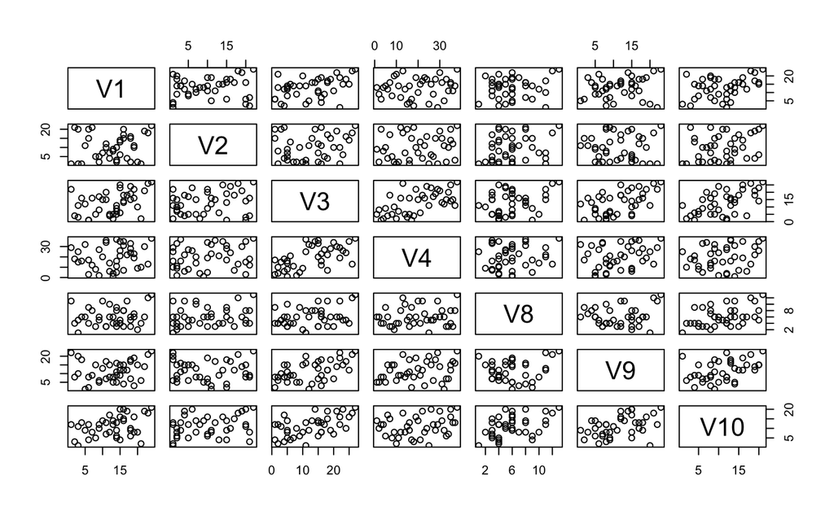

```r
# peruvians = read.table('peruvians.txt',header = FALSE)
# <!-- par(mfrow=c(1,3)) -->
# plot(V2~V6,data=peruvians); abline(0,1)
# names(peruvians);
# plot(peruvians$V2,peruvians$V6);
# boxplot(clouds$V1)
# boxplot(clouds[,1]-clouds[,2])
peruvians = read.table('peruvians.txt')
peruvians = peruvians[,-c(5,6,7)]
pairs(peruvians)
```

#### 2. Perform a test for each of the variables to test the rank correlation between that variable and migration. Give your conclusions of each test separately.

```r
age=as.numeric(levels(peruvians$V1))[peruvians$V1]
```

```
NAs introduced by coercion
```

```r
age=age[2:end(age)]
```

```
numerical expression has 2 elements: only the first used
```

```r
migration=as.numeric(levels(peruvians$V2))[peruvians$V2]
```

```
NAs introduced by coercion
```

```r
migration=migration[2:end(migration)]
```

```
numerical expression has 2 elements: only the first used
```

```r
weight=as.numeric(levels(peruvians$V3))[peruvians$V3]
```

```
NAs introduced by coercion
```

```r
weight=weight[2:end(weight)]
```

```
numerical expression has 2 elements: only the first used
```

```r
length=as.numeric(levels(peruvians$V4))[peruvians$V4]
```

```
NAs introduced by coercion
```

```r
length=length[2:end(length)]
```

```
numerical expression has 2 elements: only the first used
```

```r
wrist=as.numeric(levels(peruvians$V8))[peruvians$V8]
```

```
NAs introduced by coercion
```

```r
wrist=wrist[2:end(wrist)]
```

```
numerical expression has 2 elements: only the first used
```

```r
systolic=as.numeric(levels(peruvians$V9))[peruvians$V9]
```

```
NAs introduced by coercion
```

```r
systolic=systolic[2:end(systolic)]
```

```
numerical expression has 2 elements: only the first used
```

```r
diastolic=as.numeric(levels(peruvians$V10))[peruvians$V10]
```

```
NAs introduced by coercion
```

```r
diastolic=diastolic[2:end(diastolic)]
```

```
numerical expression has 2 elements: only the first used
```

```r
cor(age,migration)
```

```
[1] 0.5882125
```

```r
cor(weight,migration)
```

```
[1] 0.4811534
```

```r
cor(length,migration)
```

```
[1] 0.07259415
```

```r
cor(wrist,migration)
```

```
[1] 0.2369046
```

```r
cor(systolic,migration)
```

```
[1] -0.08748046
```

```r
cor(diastolic,migration)
```

```
[1] 0.07579214
```

By the numbers here above, we can confirm what was before stated that the variable which is most likely to be correlated to migration is age. The other variables had a very low or even negative values. The variable “weight” had correlation of 0.4811, which is not as low as the others, however we can’t consider here it being correlated to “migration” as this value is still low.

## EXERCISE 2

#### 1. Study the data and make a few graphical representations.

The best way to represent this data is through separating it into two different datasets: one for “lemo” and another for “energy”.

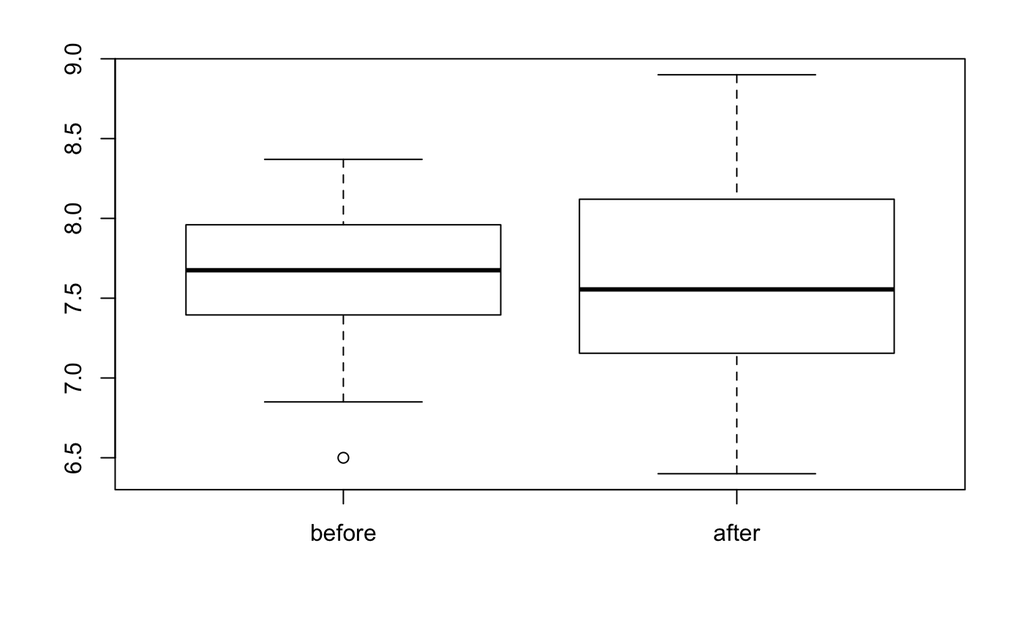

```r
run = read.table('run.txt')
lemo = subset(run,drink=="lemo")[,-c(3)]
energy = subset(run,drink=="energy")[,-c(3)]
boxplot(run[,-c(3)])
par(mfrow=c(1,1))
```

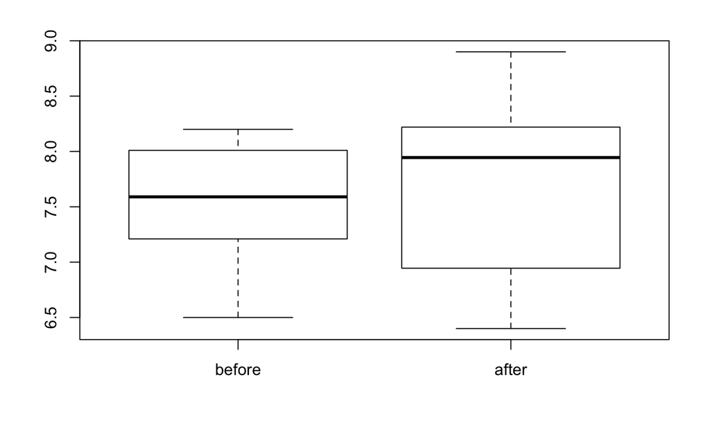

```r
boxplot(lemo)
```

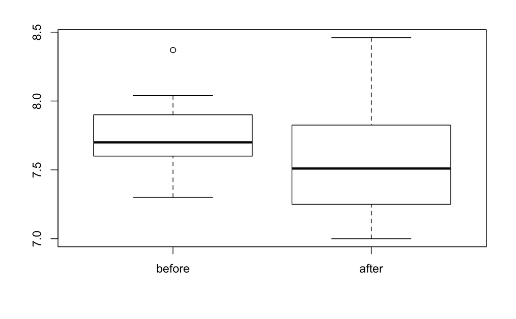

```r
boxplot(energy)
```

#### 2. Test separately, for both the softdrink and the energy drink conditions, whether there is a difference in speed in the two running tasks.

```r
t.test(lemo$before, lemo$after);
```

```
    Welch Two Sample t-test

data:  lemo$before and lemo$after
t = -0.5036, df = 18.989, p-value = 0.6203
alternative hypothesis: true difference in means is not equal to 0
95 percent confidence interval:
 -0.7476599  0.4576599
sample estimates:
mean of x mean of y
 7.554167  7.699167
```

```r
t.test(energy$before, energy$after);
```

```
    Welch Two Sample t-test

data:  energy$before and energy$after
t = 0.97741, df = 18.854, p-value = 0.3407
alternative hypothesis: true difference in means is not equal to 0
95 percent confidence interval:
 -0.1761393  0.4844726
sample estimates:
mean of x mean of y
 7.732500  7.578333
```

The results of the t.test show that, for those having drunk “lemo”, the hypothesis H0 which states that the mean values before and after drinking the beverage are equal, is maintained as the p-value of 0.6203 is clearly higher than 0.05. For the beverage “energy”, the p-value of 0.3407 maintains the hypothesis H0, however with lower value, which could suggest that, for instance, the energy could have made a difference in the overall performance.

#### 3. For each pupil compute the time difference between the two running tasks. Test whether these time differences are effected by the type of drink.

```r
run$difference = run$after - run$before
difference_lemo = subset(run,drink=="lemo")$difference
difference_energy = subset(run,drink=="energy")$difference
t.test(difference_lemo, difference_energy)
```

```
    Welch Two Sample t-test

data:  difference_lemo and difference_energy
t = 1.4764, df = 16.509, p-value = 0.1586
alternative hypothesis: true difference in means is not equal to 0
95 percent confidence interval:
 -0.1293076  0.7276409
sample estimates:
 mean of x  mean of y
 0.1450000 -0.1541667
```

#### 4. Can you think of a plausible objection to the design of the experiment if the main aim was to test whether drinking the energy drink speeds up the running?

One objection would be, since it is expected that the energy drink takes some time to take effect in the pupils’ metabolism, the data collected could have also considered that the same amount of beverage can be absorved differently by the pupils and thus, the results might end misleading or even not leading to any conclusion whatsoever.

#### 5. Is there a similar objection to the design relative to the analysis under 3)?

For the same reasons, the metabolism of the pupils react differently. For instance, regardless of what beverage was consumed, a very slim and short person would not present a difference proportional to a chubbier person with more height, under normal circumstances. Thus, the height and the weight of the pupils could have been taken into account.

#### 6. The vector of differences in 3) has 24 elements. Which distributional assumption on these differences is needed for the analysis in 3)? How would you transform this vector into 24 residuals to investigate this assumption in QQ-plots? Make this QQ-plot(s).

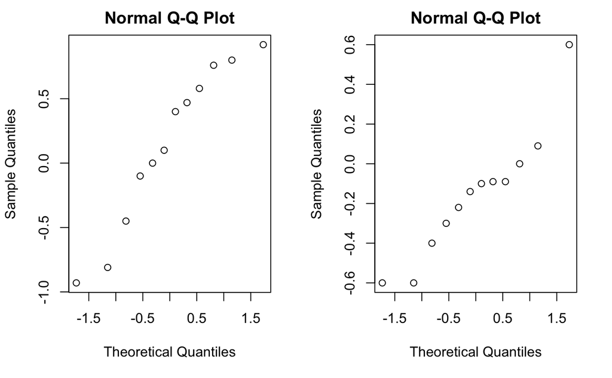

```r
par(mfrow=c(1,2))
qqnorm(difference_lemo)
qqnorm(difference_energy)
```